# STAT 240 Discussion 4

### 5

> Read in the data for Denver using the appropriate `read_*()` command. Make a line plot that shows the total number of international flights arriving to Denver international airport by month. (Note: add `group = 1` as an aesthetic so that there is a single line for all months.)

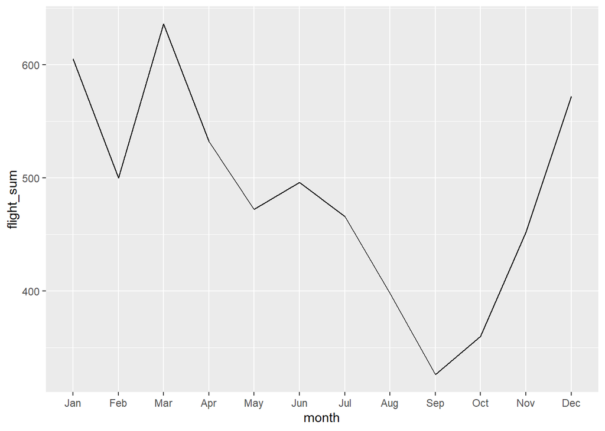

```r
den = read_csv("../../data/denver-2018.csv") %>%
  select(-ends_with("wait")) %>%
  select(-contains("_n_")) %>%
  select(-terminal,-hour,-all_excluded,-all_booths) %>%
  rename(passengers = all_total,
         flights = all_flights) %>%
  group_by(airport,date) %>%
  summarize(passengers = sum(passengers),
            flights = sum(flights)) %>%
  mutate(date = mdy(date)) %>%
  mutate(wday = wday(date, label=TRUE)) %>%
  mutate(month = month(date, label=TRUE)) %>%
  select(airport,date,month,wday,everything()) %>%
  arrange(date) %>%
  group_by(month) %>%
  summarise(flight_sum=sum(flights),passenger_sum=sum(passengers))

ggplot(data = den) +
  geom_line(mapping = aes(x = month, y = flight_sum, group = 1))
```

### Lubridate practice

Code below creates a datetime object with the current date and time. Write one line of code to extract from this datetime the requested information. (Your answers will depend on the exact time you knit the document.)

```r
now_dt = now()
```

### 6

> The year

```r
year(now_dt)
```

```
## [1] 2020
```

### 7

> The month as a number

```r
month(now_dt)
```

```
## [1] 9
```

### 8

```r
mday(now_dt)
```

```
## [1] 24
```

### 9

> The day of the week as a label

```r
wday(now_dt, label = TRUE, abbr = FALSE)
```

```
## [1] Thursday
## 7 Levels: Sunday < Monday < Tuesday < Wednesday < Thursday < ... < Saturday
```

### 10

> The hour

```r
hour(now_dt)
```

```
## [1] 16
```